# analysis

## Invasive Plants in the US: A Growing Ecological Concern

Invasive plant species are a threat to native biodiversity, agricultural productivity, and entire ecosystems. This dataset from the US Forest Service provides an up to date observation of plant infestation across the country.

From the perspective of Data Science we can...

- Analyze real-world environmental data that effect our communities
- Draw insights from structured observational records
- Identify trends and patterns from the spread of invasive species

This analysis will provide us with the capability to be more informed about environmental concerns and how we can play our own part

## Load and Inspect Data

```python
import pandas as pd

df = pd.read_csv("data/invasive_plants.csv")
df.info()
df.head()
df.columns
```

```
<class 'pandas.core.frame.DataFrame'>
RangeIndex: 875908 entries, 0 to 875907
Data columns (total 36 columns):
 #   Column                        Non-Null Count   Dtype
---  ------                        --------------   -----
 0   OBJECTID                      875908 non-null  int64
 1   SITE_ID_FS                    875908 non-null  object
 2   ACCEPTED_PLANT_CODE           875908 non-null  object
 3   ACCEPTED_SCIENTIFIC_NAME      875908 non-null  object
 4   ACCEPTED_COMMON_NAME          875164 non-null  object
 5   NRCS_PLANT_CODE               875908 non-null  object
 6   SCIENTIFIC_NAME               873508 non-null  object
 7   COMMON_NAME                   875136 non-null  object
 8   LIFEFORM_DOMINANT             242632 non-null  object
 9   PROJECT_CODE                  487163 non-null  object
```

[output cut: 28 more lines]

```
Index(['OBJECTID', 'SITE_ID_FS', 'ACCEPTED_PLANT_CODE',
       'ACCEPTED_SCIENTIFIC_NAME', 'ACCEPTED_COMMON_NAME', 'NRCS_PLANT_CODE',
       'SCIENTIFIC_NAME', 'COMMON_NAME', 'LIFEFORM_DOMINANT', 'PROJECT_CODE',
       'PROTOCOL_NAME', 'DATE_COLLECTED', 'DATE_COLLECTED_MOST_RECENT',
       'CURRENT_MEASUREMENT', 'TREATMENT_PRIORITY', 'TOTAL_AREA',
       'INFESTED_AREA', 'INFESTED_PERCENT', 'PLANT_STATUS_SET', 'COVER_PCT',
       'DISTANCE_TO_WATER_HORIZONTAL', 'DISTANCE_TO_WATER_VERTICAL',
       'OWNER_NAME', 'FS_UNIT_ID', 'FS_UNIT_NAME', 'FEATURE_CN', 'INPAVEG_CN',
       'SPATIAL_ID', 'LAST_UPDATE', 'GIS_ACRES', 'GIS_MILES', 'EXAMINERS',
       'PLANT_STATUS', 'CRC_VALUE', 'SHAPEAREA', 'SHAPELEN'],
      dtype='object')
```

## Preprocessing and Cleaning

For readability I will make the column names lower case.

To ensure usablity I will convert Data types such as objects to datetime and specific numeric fields to float.

For simplicity I will strip all objects using dates and time to just dates.

To reduce clutter of incomplete analyses, I will drop columns missing a large amount of data.

```python
# Improve Readability of Columns
df.columns = df.columns.str.strip().str.lower()

# Converting Data Types
df['last_update'] = pd.to_datetime(df['last_update'], errors='coerce')
df['date_collected'] = pd.to_datetime(df['date_collected'], errors='coerce')
df['date_collected_most_recent'] = pd.to_datetime(df['date_collected_most_recent'], errors='coerce')
df['infested_percent'] = pd.to_numeric(df['infested_percent'], errors='coerce')

# Stripping Objects of Time
df['last_update'] = df['last_update'].dt.date
df['date_collected'] = df['date_collected'].dt.date
df['date_collected_most_recent'] = df['date_collected_most_recent'].dt.date

# Dropping Columns Missing >80% of Data
threshold = 0.8
df = df.loc[:, df.isnull().mean() < threshold]
```

## Preview of Questions

In this section, I will pose some questions that we can answer through this dataset. Read through these and keep them in mind to build your own perspective and feel more immersed in the data. These will be revisited.

# Question 1

Which FS Units contain the most severe infestations?

# Question 2

What proportion of affected sites are fully infested?

# Question 3

How does the infestation severity vary across observed records?

# Question 4

In places affected by infestations, is there apparent vegetation?

# Question 5

Is there any correlation between vegetative cover and infestation severity?

# Question 6

Can any patterns be seen in the severity of infestations over time?

## Exploratory Data Analysis and Visualization

```python
# Changes scientific notation display to a regular decimal format for ease of reading
pd.set_option('display.float_format', '{:.2f}'.format)

# Overview
df.shape
df.columns
df.dtypes
df.describe()
```

|  | objectid | total_area | infested_area | infested_percent | cover_pct | fs_unit_id | gis_acres | gis_miles | shapearea | shapelen |
| --- | --- | --- | --- | --- | --- | --- | --- | --- | --- | --- |
| count | 875908.00 | 875908.00 | 875908.00 | 875908.00 | 431489.00 | 875908.00 | 875908.00 | 875908.00 | 875908.00 | 875908.00 |
| mean | 1772345.40 | 13.69 | 10.38 | 80.38 | 17.33 | 482.75 | 13.69 | 0.76 | 0.00 | 0.01 |
| std | 350536.11 | 3472.37 | 3456.92 | 35.85 | 26.59 | 308.48 | 3472.37 | 3.78 | 0.00 | 0.07 |
| min | 1240939.00 | 0.00 | 0.00 | 0.00 | 0.00 | 102.00 | 0.00 | 0.00 | 0.00 | 0.00 |
| 25% | 1484274.75 | 0.03 | 0.01 | 91.00 | 1.00 | 209.00 | 0.03 | 0.03 | 0.00 | 0.00 |
| 50% | 1728890.50 | 0.11 | 0.10 | 100.00 | 5.00 | 417.00 | 0.11 | 0.06 | 0.00 | 0.00 |
| 75% | 1974903.25 | 1.07 | 0.65 | 100.00 | 20.00 | 805.00 | 1.07 | 0.24 | 0.00 | 0.00 |
| max | 2514265.00 | 3070834.87 | 3070834.87 | 100.00 | 100.00 | 1005.00 | 3070834.87 | 482.78 | 1.22 | 8.62 |

## Dataset Overview

The dataset covers a total of 875,908 records describing invasive plant species. The table above describes the data after the proper preprocessing and cleaning to allow for a proper analysis.

# Statistical Summary

**Infestation Metrics**

- Infested Area and Total Area are both heavily right-skewed, with most values being under 1 acre, but a maximum of over 3 million acres. From this we can assume there exists a small numnber of extreme infestations that heavily influence averages.
- Infested Percent shows a median and upper quartile of 100%. This indicates that in most cases the infestation fully occupies the affected site.

**Vegetation Coverage**

- Cover Percentage(Cover PCT) has a median of 5%, ranging from 0% to 100%. This implies that many sites are sparsely vegatated, with a few that have full coverage.

**Geospatial Metrics**

- GIS Acres(representing the infestation area in acres) is identical to the Total Area. As before a heavily right skew is indicated.
- GIS Miles(representing the length of infestation features linearly). Most values are below 1 while the max is 482.78, this suggests that a few extremely long infestations exist.
- Shape Area and Shape Len contain raw geometric data and do not provide much analytical insight.

**Identifiers**

- Object ID provides identification of each record and can be disregarded for our current analytical purposes.
- FS Unit ID indicates administrative boundaries for organization and can be helpful for grouping.

## Exploratory Data Analysis

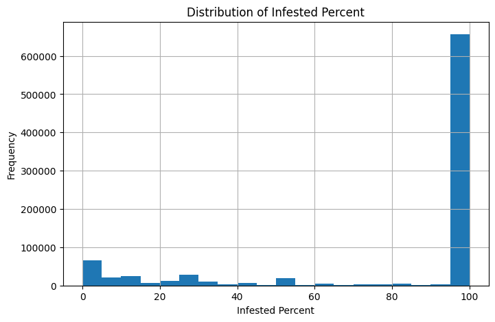

```python
# Histogram of Infested Percent
import matplotlib.pyplot as plt

plt.figure(figsize=(8,5))
df['infested_percent'].hist(bins=20)
plt.title('Distribution of Infested Percent')
plt.xlabel('Infested Percent')
plt.ylabel('Frequency')
plt.grid(True)
plt.show()
```

# Histogram of Infested Percent

This insight suggests that many infestations are uninterrupted and went without addressing over time. This may indicate a problem with our ability to detect infestations or a problem with our ability to combat infestations once started.

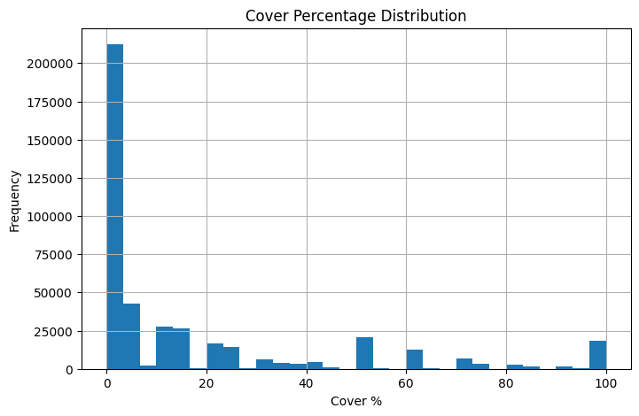

```python
# Histogram of Cover Percentage
df['cover_pct'].dropna().plot(kind='hist', bins=30, title='Cover Percentage Distribution', figsize=(8,5))
plt.xlabel('Cover %')
plt.grid(True)
plt.show()
```

# Histogram of Cover Percentage

From this insight, it may indicate that many infestations exploit degraded lands and move in before native vegetation has a chance to rebuild. The data may also imply that these areas are still in the beginning stages of invasive infestation and the invasive species has yet to fully take over the site.

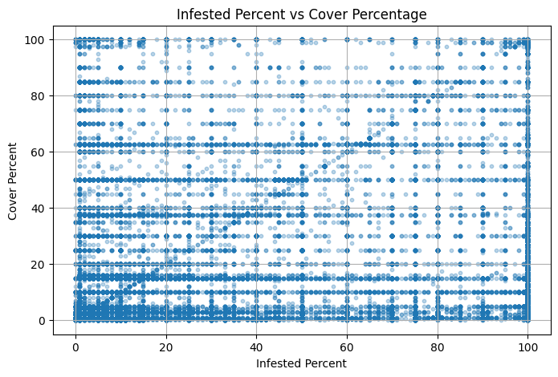

```python
# Scatter Plot of Infested Percent vs Cover Percentage
plt.figure(figsize=(8,5))
plt.scatter(df['infested_percent'], df['cover_pct'], alpha = 0.3, s = 10)
plt.title('Infested Percent vs Cover Percentage')
plt.xlabel('Infested Percent')
plt.ylabel('Cover Percent')
plt.grid(True)
plt.show()
```

# Scatter Plot of Infested Percent vs Cover Percentage

This scatter plot compares the distribution of Infested Percent vs Cover Percentage. From the data we can see no clear correlation, as infestations seemingly occur across the entire range of vegetative cover.

This implies that vegetative cover is not a reliable indicator of the severity of an infestation. From the wide spread data, we may believe that invasive species can, in certain instances, coexist with dense plant communities.

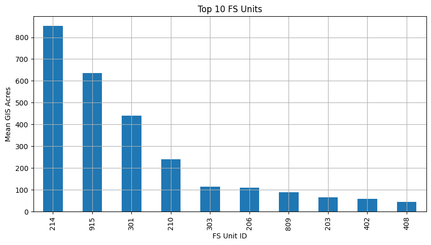

```python
# Bar Chart of Mean Infested Area per FS Unit
df.groupby('fs_unit_id')['gis_acres'].mean().sort_values(ascending=False).head(10).plot(kind='bar', figsize=(10,5))
plt.title('Top 10 FS Units')
plt.xlabel('FS Unit ID')
plt.ylabel('Mean GIS Acres')
plt.grid(True)
plt.show()
```

# Bar Chart of Mean Infested Area per FS Unit

This bar chart displays the top 10 FS Units ranked by their mean Infested Area by GIS Acres. Unit 214 stands out with a significantly higher average infestation compared to the rest of the units. Units 915 and 301 also stand out among the others. Around the 3rd to 4th spot a steep drop off is shown meaning that only a few units bear a disproportionate amount of large-scale invasions.

This points to the idea that infestations may be more severe in areas with specific conditions. These specific conditions could range from lower management activity to a more ecologically vulnerable area.

## Conclusive Answers to Our Questions

# Question 1

Which FS Units contain the most severe infestations?

When measuring the severity of Infestations for FS Units, we can take two approaches. The first would be by GIS Acres, which would measure how large infestations are on average. Whereas the second approach would be the Infested Percent, which would give the proportion of the site infested.

```python
# First Approach -> GIS Acres
avg_area = df.groupby('fs_unit_id')['gis_acres'].mean().sort_values(ascending=False)
avg_area.head(10)
```

```
fs_unit_id
214   853.41
915   636.39
301   440.42
210   240.82
303   115.33
206   110.67
809    89.77
203    66.18
402    58.41
408    44.92
Name: gis_acres, dtype: float64
```